# Practica

Agustin Riquelme y Heriberto Espino

2023-09-06

Con el objetivo de sintetizar las líneas de código lo más posible, se ha creado una función que requerirá como argumentos la variable de respuesta y la variable predictora para el modelo, así como el nivel de significancia α. Esta función se utilizará a lo largo del presente documento. Con el fin de visualizar los datos de manera más amigable, el código de la función se ocultará en el informe, pero se mantendrá en formato markdown para su correcta ejecución.

A continuación se presentarán los resultados obtenidos para cada modelo de regresión lineal simple. En estos análisis, la variable “sales” se considera como la variable de respuesta, mientras que los gastos de marketing en cada una de las plataformas se tratan como las variables predictoras. Esto se debe a que las ventas pueden estar relacionadas con el medio a través del cual se realiza el marketing. En este contexto, podemos utilizar estos modelos para predecir las ventas en función de una campaña de marketing ya propuesta y determinar si es óptima o no.

Para el modelo de regresión que involucra las ventas y el marketing en televisión, los resultados son los siguientes:

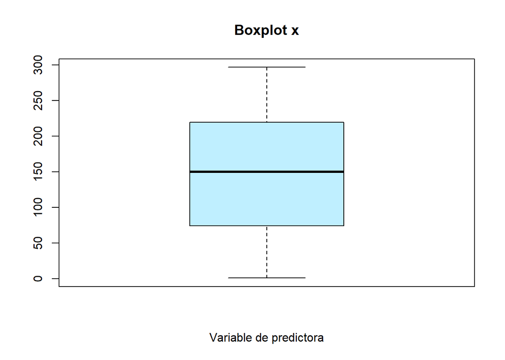

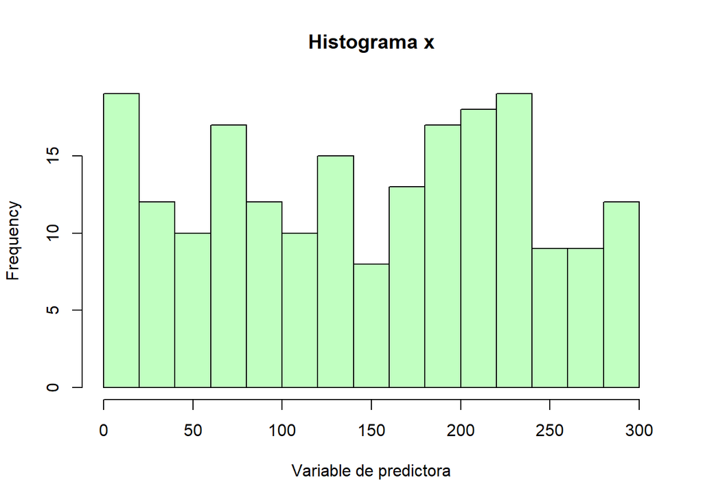

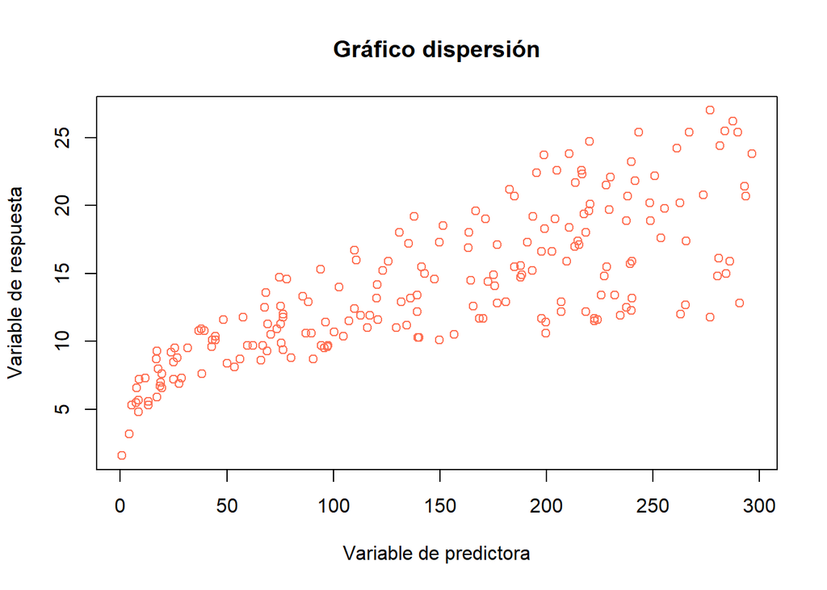

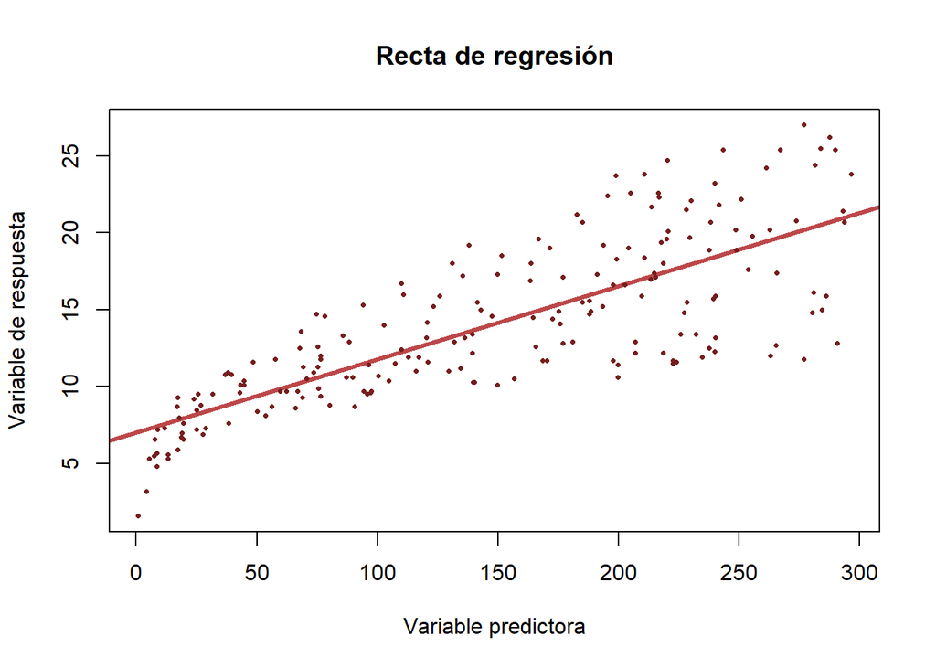

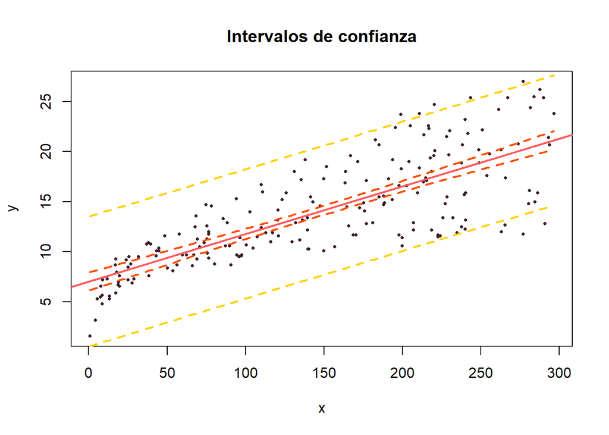

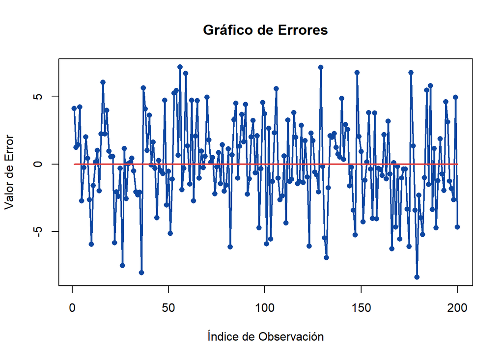

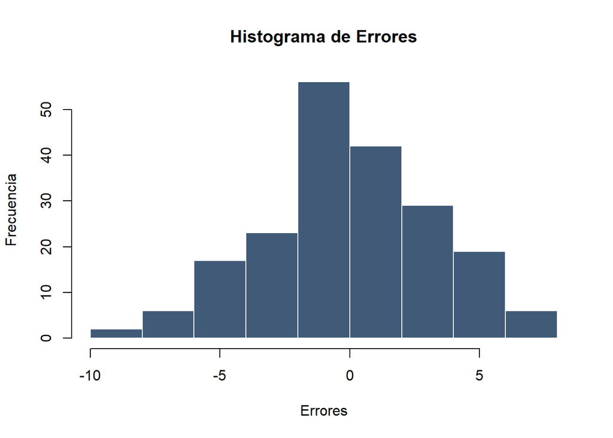

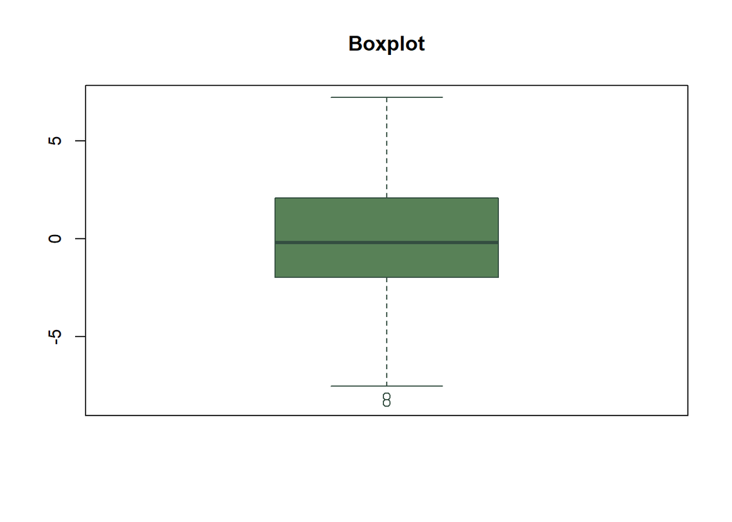

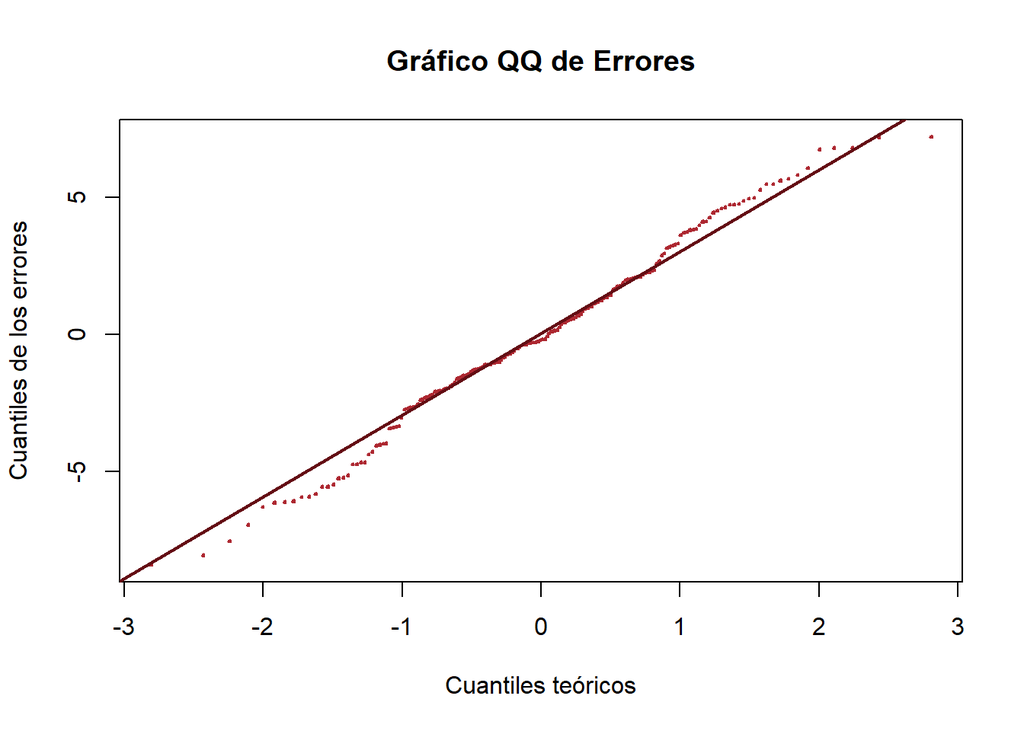

```
## Como el pvalor ≥ α, no rechazamos H0(los datos son normales),
##                   y no hay evidencia que garantice que NO son normales
##  0.2170327 ≥ 0.05Como el pvalor ≥ α, no rechazamos H0(los datos son normales),
##                   y no hay evidencia que garantice que NO son normales
##  0.5460762 ≥ 0.05Hay una correlación fuerte, coeficiente de correlación de Pearson: 0.7822244Hay una correlación fuerte, coeficiente de correlación de Spearman: 0.8006144
```

```r
linealmodel(tv, sales, 0.05)
```